# Common Mistakes

## The pipe and verbs

## The pipe

Suppose I have a dataset called `titanic`, and I want to see the first two rows. The following are equivalent:

```r
head(titanic, 2)
```

```
##   Survived Pclass                                               Name
## 1        0      3                             Mr. Owen Harris Braund
## 2        1      1 Mrs. John Bradley (Florence Briggs Thayer) Cumings
##      Sex Age Siblings.Spouses.Aboard Parents.Children.Aboard    Fare
## 1   male  22                       1                       0  7.2500
## 2 female  38                       1                       0 71.2833
```

```r
titanic %>% head(2)
```

```
##   Survived Pclass                                               Name
## 1        0      3                             Mr. Owen Harris Braund
## 2        1      1 Mrs. John Bradley (Florence Briggs Thayer) Cumings
##      Sex Age Siblings.Spouses.Aboard Parents.Children.Aboard    Fare
## 1   male  22                       1                       0  7.2500
## 2 female  38                       1                       0 71.2833
```

## The pipe

Now suppose I want to make a new variable consisting of the Fare paid, rounded to the nearest whole number:

```r
titanic %>%
  round(Fare)
```

```
## Error in function_list[[k]](value): object 'Fare' not found
```

## The pipe

Now suppose I want to make a new variable consisting of the Fare paid, rounded to the nearest whole number:

```r
round(titanic, Fare)
```

```
## Error in eval(expr, envir, enclos): object 'Fare' not found
```

## The pipe

Now suppose I want to make a new variable consisting of the Fare paid, rounded to the nearest whole number:

```r
titanic %>%
  round(titanic$Fare)
```

```
## Error in Math.data.frame(structure(list(Survived = c(0L, 1L, 1L, 1L, 0L, : non-numeric variable(s) in data frame: Name, Sex
```

## The pipe

Now suppose I want to make a new variable consisting of the Fare paid, rounded to the nearest whole number:

```r
round(titanic, titanic$Fare)
```

```
## Error in Math.data.frame(structure(list(Survived = c(0L, 1L, 1L, 1L, 0L, : non-numeric variable(s) in data frame: Name, Sex
```

—> No $ or [] in the Tidyverse!

## The pipe

Now suppose I want to make a new variable consisting of the Fare paid, rounded to the nearest whole number:

```r
titanic %>% mutate(
  round(Fare)
) %>% select(Fare)
```

```
##         Fare
## 1     7.2500
## 2    71.2833
## 3     7.9250
## 4    53.1000
## 5     8.0500
## 6     8.4583
## 7    51.8625
## 8    21.0750
## 9    11.1333
## 10   30.0708
## 11   16.7000
## 12   26.5500
## 13    8.0500
## 14   31.2750
```

[output cut: 873 more lines]

## The pipe

Now suppose I want to make a new variable consisting of the Fare paid, rounded to the nearest whole number:

```r
titanic %>% mutate(
  Fare = round(Fare)
) %>% select(Fare)
```

```
##     Fare
## 1      7
## 2     71
## 3      8
## 4     53
## 5      8
## 6      8
## 7     52
## 8     21
## 9     11
## 10    30
## 11    17
## 12    27
## 13     8
## 14    31
```

[output cut: 873 more lines]

## Designing code to do the work for you

## An obvious situation

Suppose you are asked to add 1575 to 287, then divide by 16, and have R print out the answer.

```r
## I did this by hand on a piece of paper
ans <- 116.375
ans
```

```
## [1] 116.375
```

## An obvious situation

Suppose you are asked to add 1575 to 287, then divide by 16, and have R print out the answer.

```r
ans <-(1575+287)/16
ans
```

```
## [1] 116.375
```

## An obvious situation

Oops - I meant to say divide by 15, not 16!

```r
ans <-(1575+287)/15
ans
```

```
## [1] 124.1333
```

## A less obvious situation

Was my birthday within 35 days of Thanksgiving 2018?

```r
mdy("April 2, 2018") %within%
  interval(mdy("October 14, 2018"),
           mdy("December 23, 2018"))
```

```
## [1] FALSE
```

## A less obvious situation

Oops - Thanksgiving was November 22. I used November 18 Oops - I meant to check my brother's birthday, not my own. Oops - I mean to look 30 days before and after, not 35.

```r
mdy("April 2, 2018") %within%
  interval(mdy("October 14, 2018"),
           mdy("December 23, 2018"))
```

… ugh, gotta start all over!

## A better solution

Was my birthday within 35 days of Thanksgiving 2018?

```r
my_bday <- mdy("April 2, 2018")
tgiving <- mdy("November 18, 2018")
dist <- days(35)

my_bday %within%
  interval(tgiving - dist,
           tgiving + dist)
```

```
## [1] FALSE
```

## A better solution

Oops - Thanksgiving was November 22. I used November 18 Oops - I meant to check my brother's birthday, not my own. Oops - I mean to look 30 days before and after, not 35.

```r
my_bday <- mdy("April 2, 2018")
tgiving <- mdy("November 18, 2018")
dist <- days(35)

my_bday %within%
  interval(tgiving - dist,
           tgiving + dist)
```

```
## [1] FALSE
```

## A better solution

Oops - Thanksgiving was November 22. I used November 18 Oops - I meant to check my brother's birthday, not my own. Oops - I mean to look 30 days before and after, not 35.

```r
my_bday <- mdy("November 6, 2018")
tgiving <- mdy("November 22, 2018")
dist <- days(30)

my_bday %within% interval(tgiving - dist, tgiving + dist)
```

```
## [1] TRUE
```

… Easy peasy!

## Object Types

## Object types

- What type of object you are referencing:
- A data frame
- A list
- A vector
- A variable in a dataset (so a vector)
  - Numeric? (integer?)
  - Character? (aka String)
  - Boolean?
  - Factor?
  - DateTime?
- This is important when deciding input to functions

## Object Types

```r
thing_1 <- "1989-04-02"
thing_2 <- 1989-04-02
thing_3 <- "April 2, 1989"
thing_4 <- April 2, 1989

class(thing_1)
class(thing_2)
class(thing_3)
class(thing_4)
```

## Object Types

```r
thing_1 <- "1989-04-02"
thing_2 <- 1989-04-02
thing_3 <- "April 2, 1989"
thing_4 <- April 2, 1989

class(thing_1)
class(thing_2)
class(thing_3)
class(thing_4)
```

```
## Error: <text>:4:18: unexpected numeric constant
## 3: thing_3 <- "April 2, 1989"
## 4: thing_4 <- April 2
##                     ^
```

## Object Types

```r
thing_1 <- "1989-04-02"
thing_2 <- 1989-04-02
thing_3 <- "April 2, 1989"

ymd(thing_1)
ymd(thing_2)
mdy(thing_3)
```

## Object Types

```r
thing_1 <- "1989-04-02"
thing_2 <- 1989-04-02
thing_3 <- "April 2, 1989"

ymd(thing_1)
```

```
## [1] "1989-04-02"
```

```r
ymd(thing_2)
```

```
## [1] NA
```

```r
mdy(thing_3)
```

```
## [1] "1989-04-02"
```

## To Quote or not to Quote?

## When to quote?

We (basically) never put quotes around existing object names.

```r
bob <- 1:10
mean("bob")
```

```
## [1] NA
```

## When to quote?

We (basically) never put quotes around existing object names.

There are exceptions to every rule…

```r
## Base R
dat <- data.frame(bob = 1:10)
mean(dat[,"bob"])
```

```
## [1] 5.5
```

## When to quote?

However, we do often use quotes to assign/change names of objects.

```r
dat <- data.frame(bob = 1:3)
names(dat) <- "joe"
dat
```

```
##   joe
## 1   1
## 2   2
## 3   3
```

## When to quote?

However, we do often use quotes to assign/change names of objects.

```r
dat <- data.frame(bob = 1:3)

dat %>% rename("joe" = bob)
```

```
##   joe
## 1   1
## 2   2
## 3   3
```

## When to quote?

The Tidyverse is trying to get a way from this, and also assign names to variables without quotes.

```r
dat <- data.frame(bob = 1:3)

dat %>% rename(joe = bob)
```

```
##   joe
## 1   1
## 2   2
## 3   3
```

## When to quote?

The Tidyverse is trying to get a way from this, and also assign names to variables without quotes.

```r
dat <- data.frame(bob = 1:5, joe = 1:5)

dat %>% gather(key = name, value = num)
```

```
##    name num
## 1   bob   1
## 2   bob   2
## 3   bob   3
## 4   bob   4
## 5   bob   5
## 6   joe   1
## 7   joe   2
## 8   joe   3
## 9   joe   4
## 10  joe   5
```

## When to quote?

(This is not without controversy…)

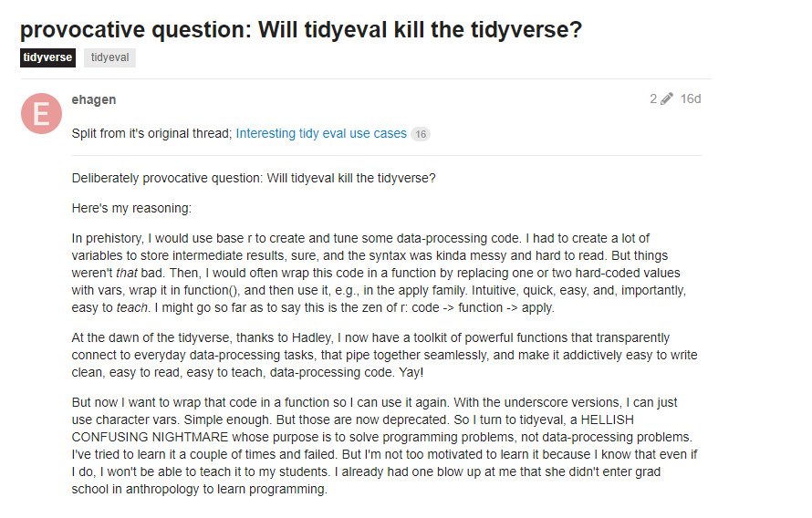

tidyeval

## When to quote?

But: never, EVER try to reference or create *values* without quotes!!!

```r
bob <- c(a, b, c)
```

## When to quote?

But: never, EVER try to reference or create *values* without quotes!!!

```r
bob <- c("a", "b", "c")
```

## When to quote?

Which of these should have quotes?

```r
titanic %>%
  mutate(
    Expensive = Fare > 100,
    Age_Group = case_when(
      Age < 18 ~ Kid,
      Age > 18 ~ Adult
    )
  ) %>%
  factor(Age_Group, levels = c(Adult, Kid)) %>%
  filter(Sex == Male)
```

## When to quote?

Which of these should have quotes?

```r
titanic %>%
  mutate(
    Expensive = Fare > 100,
    Age_Group = case_when(
      Age < 18 ~ "Kid",
      Age > 18 ~ "Adult"
    )
  ) %>%
  factor(Age_Group, levels = c("Adult", "Kid")) %>%
  filter(Sex == "Male")
```